# main_analysis

```python
import pandas as pd
import sys
import numpy as np
import math
import scipy
import matplotlib.pyplot as plt
from matplotlib import dates
import seaborn as sns
from dateutil.parser import parse
from datetime import timedelta, date
%matplotlib inline

print('Python version ' + sys.version)
print('Pandas version ' + pd.__version__)
#print('Matplotlib version ' + matplotlib.__version__)
```

```
Python version 3.6.3 |Anaconda, Inc.| (default, Oct 13 2017, 12:02:49)
[GCC 7.2.0]
Pandas version 0.20.3
```

```python
#train_sample = pd.read_csv('/home/sophia/Downloads/grocery_dataFiles/train.csv',
#                        converters={'unit_sales': lambda u: np.log1p(float(u)) if float(u) > 0 else 0},
#                         parse_dates = ['date'],
#                         skiprows = 1,
#                         dtype = {'id': 'int32', 'store_nbr': 'int32', 'item_nbr': 'int32', 'onpromotion': 'bool'},
#                         names = ['id', 'date', 'store_nbr', 'item_nbr', 'unit_sales', 'onpromotion'])
#print (train_sample.head())
```

## 1. Introduction:

```python
train_1617 = pd.read_csv('train_1617.csv', parse_dates = ['date'],
                        dtype = {'id': 'int32', 'store_nbr': 'int8', 'item_nbr': 'int32', 'onpromotion': 'bool'})
print (train_1617.dtypes)
#train_1617 = train_sample.loc[train_sample['date'] > parse('2015-08-15')]
print ('Dimention of 2016-17 training data: {}'.format(train_1617.shape))
print ('Date range of 2016-17 training data: {} - {}'.format(train_1617['date'][:1], train_1617['date'][-1:]))
#train_1617.to_csv('train_1617.csv', index = False)
train_1617.head()
```

```
id                      int32
date           datetime64[ns]
store_nbr                int8
item_nbr                int32
unit_sales            float64
onpromotion              bool
dtype: object
Dimention of 2016-17 training data: (71453276, 6)
Date range of 2016-17 training data: 0   2015-08-16
Name: date, dtype: datetime64[ns] - 71453275   2017-08-15
Name: date, dtype: datetime64[ns]
```

|  | id | date | store_nbr | item_nbr | unit_sales | onpromotion |
| --- | --- | --- | --- | --- | --- | --- |
| 0 | 54043764 | 2015-08-16 | 1 | 103665 | 0.693147 | False |
| 1 | 54043765 | 2015-08-16 | 1 | 105574 | 1.386294 | False |
| 2 | 54043766 | 2015-08-16 | 1 | 105575 | 2.079442 | False |
| 3 | 54043767 | 2015-08-16 | 1 | 106716 | 1.386294 | False |
| 4 | 54043768 | 2015-08-16 | 1 | 108079 | 0.693147 | False |

## 2. Exploratory analysis:

- Daily total sales along time for each store.
- Biweekly pairwise correlation of daily sales for all stores (mean and std).
- Features of stores and items.

```python
store_daily_sum = train_1617.groupby(['date', 'store_nbr'])['unit_sales'].sum()
store_daily_sum = store_daily_sum.add_suffix('').reset_index()
store_daily_sum['date'] = pd.DatetimeIndex(store_daily_sum['date'])
store_daily_sum.head()
```

|  | date | store_nbr | unit_sales |
| --- | --- | --- | --- |
| 0 | 2015-08-16 | 1 | 1458.702635 |
| 1 | 2015-08-16 | 2 | 3746.538041 |
| 2 | 2015-08-16 | 3 | 5447.914580 |
| 3 | 2015-08-16 | 4 | 3410.624355 |
| 4 | 2015-08-16 | 5 | 3113.658171 |

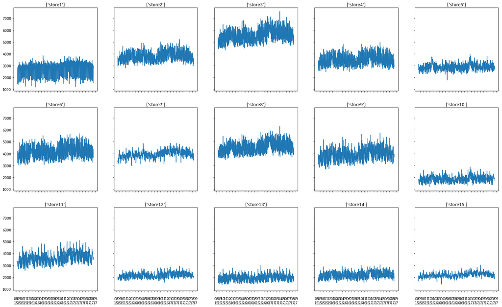

```python
fig, axes = plt.subplots(nrows=3, ncols=5, sharex=True, sharey=True, figsize=(25,15))
axes_list = [item for sublist in axes for item in sublist]

for i in range(15):
    df = store_daily_sum.loc[store_daily_sum['store_nbr'] == str(i+1)]
    axes_list[i].plot(df['date'], df['unit_sales'])
    axes_list[i].set_title(str('store' + df['store_nbr'].unique()))
    axes_list[i].xaxis.set_major_locator(dates.MonthLocator())
    axes_list[i].xaxis.set_major_formatter(dates.DateFormatter('\n%m\n%y'))
    #plt.tight_layout()
```

```python
# is a dataframe storeing daily sales data for each store, it is meant to by grouped by date
def corr_matrix(store_nbr):
    df = store_daily_sum.loc[store_daily_sum['store_nbr'] == str(store_nbr)]
    df['group_label'] = df.groupby(pd.Grouper(key='date', freq='14D', axis=1)).ngroup()
    df['dayofbiweek'] = [i for i in range(1, 15, 1)]*(df.shape[0]//14) + [i for i in range(1, (df.shape[0]%14) + 1, 1)]
    df = df.pivot(index = 'dayofbiweek', columns = 'group_label', values = 'unit_sales')
    return df.corr().as_matrix()
```

```python
count = 0
for i in range(52):
    corr = corr_matrix(store_nbr = str(i+1))
    if corr.shape == (53, 53):
        count+=1
print ('There are {} stores having complete cases of biweek correlation.'.format(count))

corr_all_stores = np.zeros((52, 53, 53))
for i in range(52):
    corr = corr_matrix(store_nbr = str(i+1))
    print
    if corr.shape == (53, 53):
        corr_all_stores[i::] = corr
    else:
        corr_all_stores[i::] = np.random.uniform(-1, 1, size = (53,53))
print ('Shape of stacks of correlation matrix: {}'.format(corr_all_stores.shape))
corr_mean = np.mean(corr_all_stores, axis = 0)
corr_std = np.std(corr_all_stores, axis = 0)
```

```
There are 47 stores having complete cases of biweek correlation.
Shape of stacks of correlation matrix: (52, 53, 53)
```

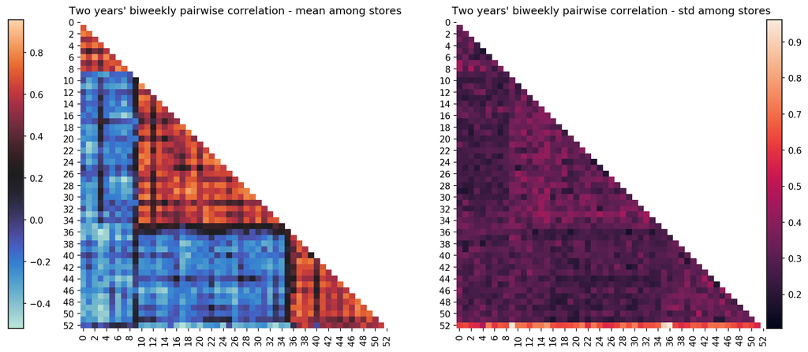

```python
import seaborn as sns
from mpl_toolkits.axes_grid1.inset_locator import inset_axes
fig, (ax1, ax2) = plt.subplots(ncols=2, figsize = (12, 6), dpi=150, facecolor='w', edgecolor='k')
mask = np.zeros_like(corr)
mask[np.triu_indices_from(mask)] = True
axins1 = inset_axes(ax1,
                   width="5%",  # width = 10% of parent_bbox width
                   height="100%",  # height : 50%
                   loc=2,borderpad=0,
                   bbox_to_anchor=(-1.45, 0., 1, 1),
                   bbox_transform=ax2.transAxes)
axins2 = inset_axes(ax2,
                   width="5%",  # width = 10% of parent_bbox width
                   height="100%",  # height : 50%
                   loc=3, borderpad=0,
                   bbox_to_anchor=(1, 0., 1, 1),
                   bbox_transform=ax2.transAxes)
with sns.axes_style("white"):
    sns.heatmap(corr_mean, ax = ax1, mask = mask, square=True, xticklabels=2, cmap="icefire", cbar = False)
    plt.colorbar(ax1.collections[0], ax=ax1, cax = axins1)
    ax1.set_title("Two years' biweekly pairwise correlation - mean among stores")
#with sns.axes_style("white"):
    sns.heatmap(corr_std, ax = ax2, mask = mask, square=True, xticklabels=2, cmap = 'rocket', cbar = False)
    plt.colorbar(ax2.collections[0], ax=ax2, cax = axins2)
    ax2.set_title("Two years' biweekly pairwise correlation - std among stores")
fig.tight_layout()
```

```python
# import seaborn as sns
# plt.figure(num=None, figsize=(6, 6), dpi=150, facecolor='w', edgecolor='k')
# corr_mean_rank = corr_mean
# corr_mean_rank[corr_mean_rank<0] = 0
# final_corr = np.zeros(corr_mean_rank.shape)
# for i in range(corr_mean_rank.shape[0]):
#     idx = np.argsort(-corr_mean_rank[i, i:])[:10]
#     final_corr[np.arange(i, corr_mean_rank.shape[1])[idx], i] = corr_mean_rank[i, i:][idx]
# mask = np.zeros_like(corr)
# mask[np.triu_indices_from(mask)] = True
# with sns.axes_style("white"):
#     ax2 = sns.heatmap(final_corr, mask = mask, square=True, xticklabels=2)
```

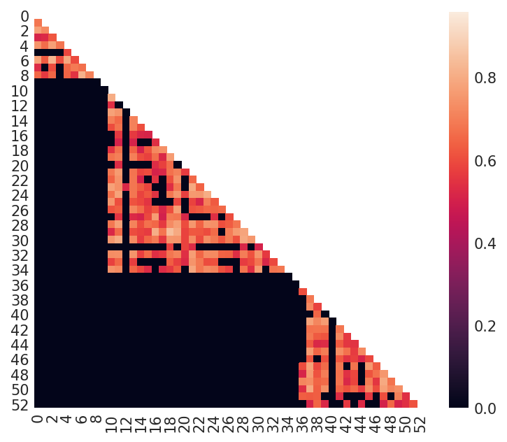

```python
import seaborn as sns
corr_mean_cutoff = corr_mean
corr_mean_cutoff[corr_mean_cutoff<0.5] = 0
plt.figure(num=None, figsize=(6, 5), dpi=150, facecolor='w', edgecolor='k')
mask = np.zeros_like(corr)
mask[np.triu_indices_from(mask)] = True
with sns.axes_style("white"):
    ax1 = sns.heatmap(corr_mean, mask = mask, xticklabels=2)
```

### Store and item features:

```python
stores = pd.read_csv('/home/sophia/Downloads/grocery_dataFiles/stores.csv',
                     dtype = {'store_nbr' : 'int32', 'cluster': 'object'})
items = pd.read_csv('/home/sophia/Downloads/grocery_dataFiles/items.csv',
                    dtype = {'item_nbr' : 'int32', 'family': 'object', 'class': 'object', 'perishable': 'bool'})
oil = pd.read_csv('/home/sophia/Downloads/grocery_dataFiles/oil.csv', names = ['date', 'oil_price'], header=0,
                 dtype = {'oil_price': 'float32'}, parse_dates = ['date'])
holidays = pd.read_csv('/home/sophia/Downloads/grocery_dataFiles/holidays_events.csv', parse_dates = ['date'])
```

```python
print ('dimention of stores = ', stores.shape)
print ('dimention of items = ', items.shape)
print ('dimention of oil = ', oil.shape)
print (stores.head(3))
print (items.head(3))
print (oil.head(3))
```

```
dimention of stores =  (54, 5)
dimention of items =  (4100, 4)
dimention of oil =  (1218, 2)
   store_nbr   city      state type cluster
0          1  Quito  Pichincha    D      13
1          2  Quito  Pichincha    D      13
2          3  Quito  Pichincha    D       8
   item_nbr     family class  perishable
0     96995  GROCERY I  1093       False
1     99197  GROCERY I  1067       False
2    103501   CLEANING  3008       False
        date  oil_price
0 2013-01-01        NaN
1 2013-01-02  93.139999
2 2013-01-03  92.970001
```

### What we learn from exploratory analysis:

- How much data to use based on the biweekly daily sales correlation matrix?

2) Correlation between months across two years is very weak. Therefore training and validation set will be selected from adjacent biweek periods.

## 3. Methods

### Assemble all features and develop train, evaluation split

train: 2017-07-01 - 2017-07-21; val: 2017-07-31 - 2017-08-15;

### Training and evaluation

Random forest and lgb

1) single model generating prediction for all dates using original features.

2) date specific models (trained for each day) generating prediction for each date involving stats features.

### Model 1 - single model generating prediction for all dates using original features

1) Extract store (state/city/cluster) and item (family/type/class) features, as well as time-series variables (i.e. oil price, holiday, day of the week, day of the month).

2) Impute missing data and transform and normalize continouis variables.

3) Label encode categorical variables (for purpose of visualizing feature importance).

```python
train_17 = train_1617.loc[train_1617['date'] >= parse('2017-07-01')]
train_17 = train_17.set_index(["id"])
train_17.head()
```

| id | date | store_nbr | item_nbr | unit_sales | onpromotion |
| --- | --- | --- | --- | --- | --- |
| 120642911 | 2017-07-01 | 1 | 99197 | 1.098612 | False |
| 120642912 | 2017-07-01 | 1 | 103520 | 1.098612 | False |
| 120642913 | 2017-07-01 | 1 | 103665 | 2.484907 | False |
| 120642914 | 2017-07-01 | 1 | 105574 | 1.098612 | False |
| 120642915 | 2017-07-01 | 1 | 105575 | 1.386294 | False |

```python
def prepare_features(df):
    print ('Assembling features ...')
    df['month'] = pd.DatetimeIndex(df['date']).month.astype('object')
    df['day'] = pd.DatetimeIndex(df['date']).day.astype('object')
    df['dayofweek'] = pd.DatetimeIndex(df['date']).dayofweek.astype('object')

    #extract features for the particular date (e.g. oil price, locations and transactions of the store, item features)
    df = df.join(oil.set_index('date'), on = 'date')
    df = df.join(stores.set_index('store_nbr'), on = 'store_nbr')
    df = df.join(items.set_index('item_nbr'), on = 'item_nbr') # extract item features

    df = df.join(holidays.set_index('date'), on = 'date', rsuffix = '_h')
    df.loc[df['type_h'].isnull(), 'type_h'] = False
    df.loc[df['type_h'] == 'Holiday', 'type_h'] = True
    df.loc[df['transferred'] == True, 'type_h'] = False

    #Holiday Step1: if it is National holiday, holiday_loc_spec is true
    df.loc[(df['type_h'] == True) & (df['locale'] == 'National'), 'type_h'] = True

    #Holiday Step2: if it is Regional holiday (state == locale_name), holiday_loc_spec is true
    df.loc[(df['type_h'] == True) & (df['locale'] == 'Regional') & (df['state'] == df['locale_name']),
              'type_h'] = True

    #Holiday tep3: if it is Local (locale_name == city), holiday_loc_spec is true
    df.loc[(df['type_h'] == True) & (df['locale'] == 'Local') & (df['city'] == df['locale_name']),
         'type_h'] = True
    df['type_h'] = df['type_h'].astype('bool')

    print ('holidays: ', df.loc[df['type_h'] == True].shape[0])
    print ('none-holidays: ', df.loc[df['type_h'] == False].shape[0])

    #Step 4: delete some columns (metadata about holidays)
    df = df.drop(['locale', 'locale_name', 'description', 'transferred'], axis=1)

    #Imputing and log transform missing oil data
    from sklearn.preprocessing import Imputer
    from sklearn.preprocessing import StandardScaler
    print ('Imputing daily oil price ...')
    print ('Missing oil price data: {}'.format(np.sum(df['oil_price'].isnull())))
    imputer = Imputer()
    df['oil_price'] = imputer.fit_transform(X = df['oil_price'].values.reshape(-1, 1))
    print ('After imputing missing data: {}'.format(np.sum(df['oil_price'].isnull())))

    df['oil_price_log'] = np.log(df['oil_price'] + 1)
    scaler = StandardScaler()
    df['oil_price_log_norm'] = scaler.fit_transform(X = df['oil_price_log'].values.reshape(-1, 1))
    #print (df['oil_price_log_norm'].describe())
    df = df.drop(['oil_price','oil_price_log'], axis = 1)
    print (df.head(3))
    #print (df.dtypes)
    return df
```

```python
train_17 = prepare_features(train_17)
train_17 = train_17.set_index(['store_nbr', 'item_nbr', 'date'])
train_17.head()
```

```
Assembling features ...
holidays:  853438
none-holidays:  4109931
Imputing daily oil price ...
Missing oil price data: 1884213
After imputing missing data: 0
                date  store_nbr  item_nbr  unit_sales  onpromotion month day  \
id
120642911 2017-07-01          1     99197    1.098612        False     7   1
120642912 2017-07-01          1    103520    1.098612        False     7   1
120642913 2017-07-01          1    103665    2.484907        False     7   1

          dayofweek  city  state  type  cluster  family  class  perishable  \
id
120642911         5    18     12     3        4      12     44       False
120642912         5    18     12     3        4      12     17       False
120642913         5    18     12     3        4       5    187        True

           type_h  oil_price_log_norm
id
120642911   False             0.01492
120642912   False             0.01492
120642913   False             0.01492
```

| store_nbr | item_nbr | date | unit_sales | onpromotion | month | day | dayofweek | city | state | type | cluster | family | class | perishable | type_h | oil_price_log_norm |
| --- | --- | --- | --- | --- | --- | --- | --- | --- | --- | --- | --- | --- | --- | --- | --- | --- |
| 1 | 99197 | 2017-07-01 | 1.098612 | False | 7 | 1 | 5 | 18 | 12 | 3 | 4 | 12 | 44 | False | False | 0.01492 |
|  | 103520 | 2017-07-01 | 1.098612 | False | 7 | 1 | 5 | 18 | 12 | 3 | 4 | 12 | 17 | False | False | 0.01492 |
|  | 103665 | 2017-07-01 | 2.484907 | False | 7 | 1 | 5 | 18 | 12 | 3 | 4 | 5 | 187 | True | False | 0.01492 |
|  | 105574 | 2017-07-01 | 1.098612 | False | 7 | 1 | 5 | 18 | 12 | 3 | 4 | 12 | 31 | False | False | 0.01492 |
|  | 105575 | 2017-07-01 | 1.386294 | False | 7 | 1 | 5 | 18 | 12 | 3 | 4 | 12 | 31 | False | False | 0.01492 |

```python
# load test data here
test = pd.read_csv('/home/sophia/Downloads/grocery_dataFiles/test.csv', parse_dates = ['date'],
                  dtype = {'id': 'int32','date': 'object', 'store_nbr': 'int32',
                           'item_nbr': 'int32', 'onpromotion': 'bool'})
test = prepare_features(test)
test = test.set_index(['store_nbr', 'item_nbr', 'date'])
```

```
Assembling features ...
holidays:  210654
none-holidays:  3159810
Imputing daily oil price ...
Missing oil price data: 842616
After imputing missing data: 0
          id       date  store_nbr  item_nbr  onpromotion month day dayofweek  \
0  125497040 2017-08-16          1     96995        False     8  16         2
1  125497041 2017-08-16          1     99197        False     8  16         2
2  125497042 2017-08-16          1    103501        False     8  16         2

   city  state  type  cluster  family  class  perishable  type_h  \
0    18     12     3        4      12     64       False   False
1    18     12     3        4      12     44       False   False
2    18     12     3        4       7    217       False   False

   oil_price_log_norm
0            -0.67532
1            -0.67532
2            -0.67532
```

```python
from  sklearn.preprocessing import LabelEncoder
train_test_features = pd.concat([train_17, test], axis = 0)

cate_features = ['city','state','type', 'cluster', 'family']
noncate_features = ['month','day', 'dayofweek','onpromotion', 'class', 'perishable', 'type_h', 'oil_price_log_norm']
data_cate = train_test_features[cate_features]
data_noncate = train_test_features[noncate_features]
#get onehot vector for category variables
#data_cate = pd.get_dummies(data_cate, sparse = True)
#just encode category variables (except class) with normalized int

encoder = LabelEncoder()
for cate_col in cate_features:
    data_cate[cate_col] = encoder.fit_transform(data_cate[cate_col].astype('str'))

fullset_features = pd.concat([data_noncate, data_cate], axis = 1,
                             join_axes=[data_noncate.index])
obj_col = ['month', 'day', 'dayofweek', 'class']
fullset_features[obj_col] = fullset_features[obj_col].astype('int16')

#fullset_features.head(3)
```

```python
y_train = train_17['unit_sales']
X_train = fullset_features.iloc[:train_17['unit_sales'].shape[0]]
X_test = fullset_features.iloc[train_17['unit_sales'].shape[0]:]
print (fullset_features.shape, X_train.shape, y_train.shape, X_test.shape)
del fullset_features
```

```
(8333833, 13) (4963369, 13) (4963369,) (3370464, 13)
```

```python
def check_coverage(df1, df2, col):
    listA = sorted(df1[col].unique())
    listB = sorted(df2[col].unique())
    if listA == listB:
        print ('All the members in df2 are included in df1.')
    else:
        print ('Not all the members in df2 are included in df1.')
        A = set(df1[col].unique())
        B = set(df2[col].unique())
        print ('there is {:.5}% new {} seen in df2 \n'. format(((B-A)/len(A)) * 100, col))
```

```python
X_train_july = X_train.loc[(X_train['month'] == 7) & (X_train['day'] <= 21)]
X_val = X_train.loc[(X_train['month'] == 8) & (X_train['day'] <= 15)]
y_train_july = y_train.iloc[:X_train_july.shape[0]]
y_val = y_train.iloc[-X_val.shape[0]:]
assert X_train_july.shape[0] == y_train_july.shape[0]
assert X_val.shape[0] == y_val.shape[0]
```

```python
def NWRMSLE(y, pred, weights_vector):
    weights = None
    y = y.clip(0, y.max())
    pred = pred.clip(0, pred.max())
    weights = np.where(weights_vector == 1, 1.25, 1.0)
    score = np.nansum(weights * ((pred - y) ** 2)) / weights.sum()
    return np.sqrt(score)

import sklearn
from sklearn.model_selection import cross_val_score
from sklearn.svm import SVR
from sklearn.tree import DecisionTreeRegressor
from sklearn.ensemble import RandomForestRegressor
from sklearn.ensemble import GradientBoostingRegressor
import matplotlib.pyplot as plt
from sklearn.metrics import mean_squared_log_error
from time import time

def train_predict(learner, X_train, y_train, X_val, y_val):
    results = {}
    learner.fit(X_train, y_train)
    results['feature_importances'] = learner.feature_importances_
    #print ('rank of feature importance: {}'.format(X_train.columns.values[np.argsort(importances)[::-1]]))


    pred_train = learner.predict(X_train)
    pred_val = learner.predict(X_val)

    results['train_score'] = NWRMSLE(y_train, pred_train, X_train.perishable.values)
    results['val_score'] = NWRMSLE(y_val, pred_val, X_val.perishable.values)

    print ('Data trained on {}'.format(learner.__class__.__name__))
    print ('traing and evaluation scores {},{}'.format(results['train_score'], results['val_score']))
    return results
```

```python
learner = RandomForestRegressor(n_estimators=300, max_features='sqrt', n_jobs=2)
train_predict(learner, X_train_july, y_train_july, X_val, y_val)
```

```
Data trained on RandomForestRegressor
traing and evaluation scores 0.6902977108302566,0.7456258076848133
```

```
{'feature_importances': array([ 0.        ,  0.03248606,  0.02701468,  0.0554976 ,  0.48914803,
         0.01681259,  0.00153912,  0.02590902,  0.04129572,  0.03906395,
         0.1000252 ,  0.05944455,  0.11176347]),
 'train_score': 0.69029771083025659,
 'val_score': 0.74562580768481335}
```

```python
X_train_july.columns[np.argsort(feature_importance)[::-1]]
```

```
Index(['class', 'family', 'type', 'cluster', 'onpromotion', 'city', 'state',
       'day', 'dayofweek', 'oil_price_log_norm', 'perishable', 'type_h',
       'month'],
      dtype='object')
```

```python
import lightgbm as lgb
from sklearn.metrics import mean_squared_error
def NWRMSLE(y, pred, weights_vector):
    weights = None
    y = y.clip(0, y.max())
    pred = pred.clip(0, pred.max())
    weights = np.where(weights_vector == 1, 1.25, 1.0)
    score = np.nansum(weights * ((pred - y) ** 2)) / weights.sum()
    return np.sqrt(score)

# create dataset for lightgbm
lgb_train = lgb.Dataset(X_train_july, y_train_july,
                        weight=X_train_july.perishable.values * 0.25 + 1)
lgb_val = lgb.Dataset(X_val, y_val, reference=lgb_train,
                     weight=X_val.perishable.values * 0.25 + 1)

MAX_ROUNDS = 1000
# specify your configurations as a dict
params = {
    'task': 'train',
    'boosting_type': 'gbdt',

    'objective': 'regression',
    'metric': 'l2_root',
    'num_leaves': 31,
    'lambda_l1':0.1,
    'num_data_in_leaf':200,
    'learning_rate': 0.05,
    'feature_fraction': 0.9,
    'bagging_fraction': 0.8,
    'bagging_freq': 5,
    'num_threads': 4
}

print('Start training...')
# train
gbm = lgb.train(params,
                lgb_train,
                num_boost_round=MAX_ROUNDS,
                valid_sets= lgb_val,
                early_stopping_rounds=50,
                verbose_eval=100
                )
print("\n".join(("%s: %.2f" % x) for x in sorted(
        zip(X_train.columns, gbm.feature_importance("gain")),
        key=lambda x: x[1], reverse=True
    )))

print('Start predicting...')
# predict
y_pred = gbm.predict(X_val, num_iteration=gbm.best_iteration or MAX_ROUNDS)
# eval
print('The mrse of validaion is:', mean_squared_error(y_val, y_pred)**0.5)
print('The NWRMSLE of validation is:', NWRMSLE(y_val, y_pred, X_val['perishable']))
```

```
Start training...
Training until validation scores don't improve for 50 rounds.
[100]	valid_0's rmse: 0.768822
[200]	valid_0's rmse: 0.758429
[300]	valid_0's rmse: 0.754298
[400]	valid_0's rmse: 0.751378
[500]	valid_0's rmse: 0.749468
[600]	valid_0's rmse: 0.748038
[700]	valid_0's rmse: 0.746698
[800]	valid_0's rmse: 0.745817
[900]	valid_0's rmse: 0.744937
[1000]	valid_0's rmse: 0.744265
Did not meet early stopping. Best iteration is:
[998]	valid_0's rmse: 0.744261
class: 1827988.14
family: 807009.20
type: 764708.75
onpromotion: 372927.42
cluster: 356830.07
state: 216500.90
city: 215455.51
dayofweek: 120581.38
oil_price_log_norm: 111110.46
day: 73314.69
perishable: 29205.78
type_h: 179.14
month: 0.00
Start predicting...
The mrse of validaion is: 0.742665947605
The NWRMSLE of validation is: 0.744261344198
```

### What we learn from this starter model:

Original features provide poor prediction that barely beats mean baseline. Features without any furture development didn't work well. The starter models indeed tell the relative importance about the store and item features, which is helpful in the later statistical feature engineering part.

### Model 2 - Generate model for each single date using involving tatistical features:

It is worthnoting that so far all the features are not closely related to target variable 'unit_sales', and most of them are categorical variables. In order to precisely predict 'unit_sales', statistical value (mean and std) of target variable over certain time period, can be used to predict target variable. Therefore an additional step to take is calculating statistical values for 'onpromotion' and 'unit_sales'. The intuation behind is to put suits of constrain on the prediction, for example using 3, 7, 14 previous days' mean and std of 'unit_sales' of a particular item X store combination to predict the future 'unit_sale' of this item X store combination.

2) It is important to choose the 'key' for the statistical features, i.e. 'onpromotion' and 'unit_sales' for what kind of entity combination (e.g. item X store, item X family, or class X store?).

3) Start from the most straight forward case 'onpromotion' and 'unit_sales' for particular store X item combination.

- begin with the 'onpromotion' and 'unit_sales' columns in 2017, make an individual dataframe for each of the variables, and indexed with store and item.
- unstack the target variable along time (cast the time series of target variables from each row to column).
- using pd.date_range() method to index particular time sequence that is of interest (for example several consecutive days, or work days). Use those indices of time spans to calculate sum (for promotion), mean and std of target variable across columns.

```python
# read selected time period of training data to generate statistical features
train_17 = train_1617.loc[train_1617['date'] >= parse('2017-01-01')]
# load test data here
test = pd.read_csv('/home/sophia/Downloads/grocery_dataFiles/test.csv', parse_dates = ['date'],
                  dtype = {'id': 'int32','date': 'object', 'store_nbr': 'int32',
                           'item_nbr': 'int32', 'onpromotion': 'bool'})
# cast the day-by-day onpromotion (T/F) value for each particular store * item
promo_train = train_17.set_index(["store_nbr", "item_nbr", "date"])[["onpromotion"]].unstack(level=-1).fillna(False)
promo_train.columns = promo_train.columns.get_level_values(1)

promo_test = test.set_index(['store_nbr', 'item_nbr', 'date'])[["onpromotion"]].unstack(level=-1).fillna(False)
promo_test.columns = promo_test.columns.get_level_values(1)

#reindex and fillna for text data because there will be new items seen in text but not in train so na is generated
promo_test = promo_test.reindex(promo_train.index).fillna(False)
promo = pd.concat([promo_train, promo_test], axis=1)
```

```python
sales_train = train_17.set_index(["store_nbr", "item_nbr", "date"])[["unit_sales"]].unstack(level=-1).fillna(0)
sales_train.columns = sales_train.columns.get_level_values(1)
```

```python
def get_timespan(df, st, minus, periods, freq='D'):
    return df[pd.date_range(st - timedelta(days=minus), periods=periods, freq=freq)]

def get_nearwd(date,b_date):
    date_list = pd.date_range(date-timedelta(140),periods=21,freq='7D').date
    result = date_list[date_list<=b_date][-1]
    return result

def prepare_dataset(t2017, is_train = True):
    X = pd.DataFrame({
        #if previous 14 days have any promo
        "promo_14days": get_timespan(promo, t2017, 14, 14).sum(axis=1).values,
        "promo_60days": get_timespan(promo, t2017, 60, 60).sum(axis=1).values,
        "promo_140days": get_timespan(promo, t2017, 140, 140).sum(axis=1).values,
        #how many days in 14 days after not having any promotion
        "unpromo_14daysAfter":
        (1-get_timespan(promo, t2017+timedelta(14), 14, 14)).iloc[:,1:].sum(axis=1).values,
    }, index = promo.index) #excluding the day itself so .iloc[:,1:]

    for i in range(7):
        X["promo_{}".format(i)] = promo[
            t2017 + timedelta(days=i)].values.astype(np.uint8)
        #for j in [14,60,140]:
        #    X["aft_promo_{}{}".format(i,j)] = (promo[t2017 + timedelta(days=i)]-1).values.astype(np.uint8)
        #    X["aft_promo_{}{}".format(i,j)] = X["aft_promo_{}{}".format(i,j)]*X['promo_{}'.format(i)]

    for i in range(7):
        X['mean_4_dow{}'.format(i)] = get_timespan(sales_train, t2017, 28-i, 4, freq='7D').mean(axis=1).values
        #X['mean_12_dow{}'.format(i)] = get_timespan(sales_train, t2017, 84-i, 12, freq='7D').mean(axis=1).values
        X['mean_20_dow{}'.format(i)] = get_timespan(sales_train, t2017, 140-i, 20, freq='7D').mean(axis=1).values

        date = get_nearwd(t2017+timedelta(i),t2017)
        #ahead = (t2017-date).days
        #if ahead!=0:
        #    X['ahead0_{}'.format(i)] = get_timespan(sales_train, date+timedelta(ahead), ahead, ahead).mean(axis=1).values
        #    X['ahead7_{}'.format(i)] = get_timespan(sales_train, date+timedelta(ahead), ahead+7, ahead+7).mean(axis=1).values
        #X["day_1_{}1".format(i)]= get_timespan(sales_train, date, 1, 1).values.ravel()
        #X["day_1_{}2".format(i)]= get_timespan(sales_train, date-timedelta(7), 1, 1).values.ravel()
        for m in [3,7,14,30,60,140]:
            X["mean_{}_{}1".format(m,i)]= get_timespan(sales_train, date, m, m).\
                mean(axis=1).values
            X["mean_{}_{}2".format(m,i)]= get_timespan(sales_train, date-timedelta(7), m, m).\
                mean(axis=1).values
            X["std_{}_{}1".format(m,i)]= get_timespan(sales_train, date, m, m).\
                std(axis=1).values
            X["std_{}_{}2".format(m,i)]= get_timespan(sales_train, date-timedelta(7), m, m).\
                std(axis=1).values
    if is_train:
        y = sales_train[pd.date_range(t2017, periods=16)].values
        return X, y
    return X
```

```python
print("Preparing dataset...")

t2017 = date(2017,7,1)
X_l, y_l = [], []
#get train_stat features calculated based on duration of (7/1 - 7/1 + 21 days)
for i in range(4):
    delta = timedelta(days=7 * i)
    X_tmp, y_tmp = prepare_dataset(
        t2017 + delta
    )
    X_l.append(X_tmp)
    y_l.append(y_tmp)
X_train_stat = pd.concat(X_l, axis=0)
y_train = np.concatenate(y_l, axis=0) # there will be 16 models for 16 date: july or aug 16-31

del X_l, y_l
t2017_val = date(2017, 7, 31)
X_val_stat, y_val = prepare_dataset(t2017_val)
X_test_stat = prepare_dataset(date(2017, 8, 16), is_train=False)
```

```
Preparing dataset...
```

```python
print (X_train_stat.shape, y_train.shape, X_val_stat.shape, y_val.shape, X_test_stat.shape)
```

```
(670060, 193) (670060, 16) (167515, 193) (167515, 16) (167515, 193)
```

```python
del promo, sales_train, train_17, train_1617
```

```python
from sklearn.preprocessing import LabelEncoder
items['perishable'] = items['perishable'].astype('bool').fillna('False')
encoder = LabelEncoder()
col_toEncode = ['city','state','type', 'cluster']
for col in col_toEncode:
    stores[col] = encoder.fit_transform(stores[col].astype('str'))
col_toEncode = ['family', 'class']
for col in col_toEncode:
    items[col] = encoder.fit_transform(items[col].astype('str'))
```

```python
def get_item_store_features(df):
    result = df.reset_index().join(stores.set_index('store_nbr'), on = 'store_nbr')
    result = result.reset_index().join(items.set_index('item_nbr'), on = 'item_nbr')
    result = result.set_index(['store_nbr', 'item_nbr'])
    result = result.drop(['index'], axis = 1)
    return result

X_train = get_item_store_features(X_train_stat)
X_val = get_item_store_features(X_val_stat)
X_test = get_item_store_features(X_test_stat)
```

```python
X_train.head()
```

| store_nbr | item_nbr | promo_140days | promo_14days | promo_60days | unpromo_14daysAfter | promo_0 | promo_1 | promo_2 | promo_3 | promo_4 | promo_5 | ... | mean_140_62 | std_140_61 | std_140_62 | city | state | type | cluster | family | class | perishable |
| --- | --- | --- | --- | --- | --- | --- | --- | --- | --- | --- | --- | --- | --- | --- | --- | --- | --- | --- | --- | --- | --- | --- |
| 1 | 96995 | 0 | 0 | 0 | 13 | 0 | 0 | 0 | 0 | 0 | 0 | ... | 0.085009 | 0.265537 | 0.255718 | 18 | 12 | 3 | 4 | 12 | 64 | False |
|  | 99197 | 0 | 0 | 0 | 13 | 0 | 0 | 0 | 0 | 0 | 0 | ... | 0.222580 | 0.499171 | 0.479354 | 18 | 12 | 3 | 4 | 12 | 44 | False |
|  | 103520 | 0 | 0 | 0 | 13 | 0 | 0 | 0 | 0 | 0 | 0 | ... | 0.760077 | 0.692766 | 0.692392 | 18 | 12 | 3 | 4 | 12 | 17 | False |
|  | 103665 | 0 | 0 | 0 | 13 | 0 | 0 | 0 | 0 | 0 | 0 | ... | 1.043700 | 0.660136 | 0.653092 | 18 | 12 | 3 | 4 | 5 | 187 | True |
|  | 105574 | 30 | 0 | 0 | 13 | 0 | 0 | 0 | 0 | 0 | 0 | ... | 1.797207 | 0.663982 | 0.661958 | 18 | 12 | 3 | 4 | 12 | 31 | False |

5 rows × 200 columns

```python
del X_train_stat, X_val_stat, X_test_stat
```

```python
# def NWRMSLE(y, pred, weights_vector):
#     weights = None
#     y = y.clip(0, y.max())
#     pred = pred.clip(0, pred.max())
#     weights = np.where(weights_vector == 1, 1.25, 1.0)
#     score = np.nansum(weights * ((pred - y) ** 2)) / weights.sum()
#     return np.sqrt(score)

# import sklearn
# from sklearn.model_selection import cross_val_score
# from sklearn.svm import SVR
# from sklearn.tree import DecisionTreeRegressor
# from sklearn.ensemble import RandomForestRegressor
# from sklearn.ensemble import GradientBoostingRegressor
# import matplotlib.pyplot as plt
# from sklearn.metrics import mean_squared_log_error
# from time import time
# def train_predict(learner, X_train, y_train, X_val, y_val):
#     results = {}
#     learner.fit(X_train, y_train)
#     print ('import features: {}'.format(X_train.columns.values[(np.argsort(learner.feature_importances_))[::-1]]))

#     pred_train = learner.predict(X_train)
#     pred_val = learner.predict(X_val)

#     results['train_score'] = NWRMSLE(y_train, pred_train, X_train.perishable.values)
#     results['val_score'] = NWRMSLE(y_val, pred_val, X_val.perishable.values)

#     print ('Data trained on {}'.format(learner.__class__.__name__))
#     print ('traing and evaluation scores {},{}'.format(results['train_score'], results['val_score']))
#     return results

# learner = RandomForestRegressor(n_estimators=300, max_features='sqrt', n_jobs=2)
# train_predict(learner, X_train, y_train[:,0].reshape(X_train.shape[0]),
#               X_val, y_val[:,0].reshape(X_val.shape[0]))
```

```python
import lightgbm as lgb
from sklearn.metrics import mean_squared_error
def NWRMSLE(y, pred, weights_vector):
    weights = None
    y = y.clip(0, y.max())
    pred = pred.clip(0, pred.max())
    weights = np.where(weights_vector == 1, 1.25, 1.0)
    score = np.nansum(weights * ((pred - y) ** 2)) / weights.sum()
    return np.sqrt(score)

# create dataset for lightgbm
lgb_train = lgb.Dataset(X_train, y_train[:,0].reshape(X_train.shape[0]),
                        weight=X_train.perishable.values * 0.25 + 1)
lgb_val = lgb.Dataset(X_val, y_val[:,0].reshape(X_val.shape[0]), reference=lgb_train,
                     weight=X_val.perishable.values * 0.25 + 1)

MAX_ROUNDS = 1000
# specify your configurations as a dict
params = {
    'task': 'train',
    'boosting_type': 'gbdt',

    'objective': 'regression',
    'metric': 'l2_root',
    'num_leaves': 31,
    'lambda_l1':0.1,
    'num_data_in_leaf':200,
    'learning_rate': 0.05,
    'feature_fraction': 0.9,
    'bagging_fraction': 0.8,
    'bagging_freq': 5,
    'num_threads': 4
}

print('Start training...')
# train
gbm = lgb.train(params,
                lgb_train,
                num_boost_round=MAX_ROUNDS,
                valid_sets= lgb_val,
                early_stopping_rounds=50,
                verbose_eval=100
                )
print("\n".join(("%s: %.2f" % x) for x in sorted(
        zip(X_train.columns, gbm.feature_importance("gain")),
        key=lambda x: x[1], reverse=True
    )))

print('Start predicting...')
# predict
y_pred = gbm.predict(X_val, num_iteration=gbm.best_iteration or MAX_ROUNDS)
# eval
print('The mrse of validaion is:', mean_squared_error(y_val[:,0], y_pred)**0.5)
print('The NWRMSLE of validation is:', NWRMSLE(y_val[:,0], y_pred, X_val['perishable']))
```

```
Start training...
Training until validation scores don't improve for 50 rounds.
[100]	valid_0's rmse: 0.574274
[200]	valid_0's rmse: 0.572442
[300]	valid_0's rmse: 0.572048
[400]	valid_0's rmse: 0.571528
[500]	valid_0's rmse: 0.57127
Early stopping, best iteration is:
[520]	valid_0's rmse: 0.571172
mean_7_01: 2008437.62
mean_14_01: 1941151.14
mean_14_61: 379461.20
mean_3_01: 341985.44
mean_20_dow0: 130621.48
mean_30_01: 113299.41
mean_4_dow0: 83737.87
mean_4_dow6: 81852.40
mean_7_61: 75215.35
promo_0: 71349.09
std_7_01: 37283.25
promo_14days: 24031.83
mean_3_21: 17290.81
mean_60_01: 15698.94
mean_4_dow1: 13099.59
std_14_01: 12863.55
std_3_01: 7993.21
unpromo_14daysAfter: 6305.90
promo_2: 5900.40
mean_3_61: 5837.14
mean_30_11: 5836.58
mean_60_21: 5305.36
mean_3_51: 4967.89
promo_1: 4677.94
mean_60_61: 4663.80
mean_30_22: 4137.79
promo_140days: 4034.42
mean_140_01: 3715.97
class: 3682.33
promo_60days: 3612.31
mean_30_12: 3357.05
```

[output cut: 157 more lines]

```
std_140_21: 197.55
mean_60_62: 196.44
std_140_42: 185.97
std_60_21: 181.64
mean_140_62: 174.70
mean_140_32: 166.93
mean_140_41: 107.93
mean_140_31: 101.87
mean_140_21: 101.70
mean_140_11: 78.77
mean_140_51: 77.52
mean_140_52: 52.96
Start predicting...
The mrse of validaion is: 0.569613285666
The NWRMSLE of validation is: 0.571146880454
```

```python
val_pred = []
MAX_ROUNDS = 400
for i in range(16):
    print("=" * 50)
    print("Step %d" % (i+1))
    print("=" * 50)
    dtrain = lgb.Dataset(
        X_train, y_train[:,i].reshape(X_train.shape[0]),
        weight=X_train["perishable"] * 0.25 + 1
    )
    dval = lgb.Dataset(
        X_val, y_val[:,i].reshape(X_val.shape[0]), reference=lgb_train,
        weight=X_val.perishable.values * 0.25 + 1
        )
    gbm = lgb.train(
        params, dtrain, num_boost_round=MAX_ROUNDS,
        valid_sets=[dtrain, dval], early_stopping_rounds=50, verbose_eval=100
    )
    #print("\n".join(("%s: %.2f" % x) for x in sorted(
    #    zip(X_train.columns, gbm.feature_importance("gain")),
    #    key=lambda x: x[1], reverse=True
    #)))
    val_pred.append(gbm.predict(
        X_val, num_iteration=gbm.best_iteration or MAX_ROUNDS))
assert y_val.shape == np.array(val_pred).transpose().shape
print("Validation msre:", mean_squared_error(y_val, np.array(val_pred).transpose())**0.5)
```

```
==================================================
Step 1
==================================================
Training until validation scores don't improve for 50 rounds.
[100]	training's rmse: 0.564131	valid_1's rmse: 0.574274
[200]	training's rmse: 0.557037	valid_1's rmse: 0.572442
[300]	training's rmse: 0.552912	valid_1's rmse: 0.572048
[400]	training's rmse: 0.549476	valid_1's rmse: 0.571528
Did not meet early stopping. Best iteration is:
[400]	training's rmse: 0.549476	valid_1's rmse: 0.571528
==================================================
Step 2
==================================================
Training until validation scores don't improve for 50 rounds.
[100]	training's rmse: 0.580672	valid_1's rmse: 0.601996
[200]	training's rmse: 0.572582	valid_1's rmse: 0.601451
Early stopping, best iteration is:
[173]	training's rmse: 0.574076	valid_1's rmse: 0.601305
==================================================
Step 3
==================================================
Training until validation scores don't improve for 50 rounds.
[100]	training's rmse: 0.583981	valid_1's rmse: 0.589135
[200]	training's rmse: 0.577641	valid_1's rmse: 0.587509
[300]	training's rmse: 0.573591	valid_1's rmse: 0.587274
[400]	training's rmse: 0.570209	valid_1's rmse: 0.586969
Did not meet early stopping. Best iteration is:
[400]	training's rmse: 0.570209	valid_1's rmse: 0.586969
==================================================
Step 4
==================================================
Training until validation scores don't improve for 50 rounds.
[100]	training's rmse: 0.576571	valid_1's rmse: 0.59387
Early stopping, best iteration is:
[90]	training's rmse: 0.577958	valid_1's rmse: 0.592946
==================================================
Step 5
==================================================
Training until validation scores don't improve for 50 rounds.
[100]	training's rmse: 0.563286	valid_1's rmse: 0.605606
```

[output cut: 91 more lines]

```
[200]	training's rmse: 0.62042	valid_1's rmse: 0.625042
[300]	training's rmse: 0.61523	valid_1's rmse: 0.624575
Early stopping, best iteration is:
[330]	training's rmse: 0.613781	valid_1's rmse: 0.624221
==================================================
Step 16
==================================================
Training until validation scores don't improve for 50 rounds.
[100]	training's rmse: 0.639132	valid_1's rmse: 0.628823
[200]	training's rmse: 0.63009	valid_1's rmse: 0.627131
[300]	training's rmse: 0.624428	valid_1's rmse: 0.626038
[400]	training's rmse: 0.620217	valid_1's rmse: 0.625717
Did not meet early stopping. Best iteration is:
[400]	training's rmse: 0.620217	valid_1's rmse: 0.625717
Validation msre: 0.608667496519
```

## 4. Steps forward

- Involving more statistical features for item X store' class, and item X store's family combination (class and family are important predictors).
- Developing training data involving data of different time length (two weeks, three weeks, four weeks).
- Fine tune the lgb with new features.
- Implement RNN model - sequence models save the steps for feature engineering, the time sequence information is learned by model.